# HW 8 & 9

Jan Netík

### 1.1.1 & 1.1.2

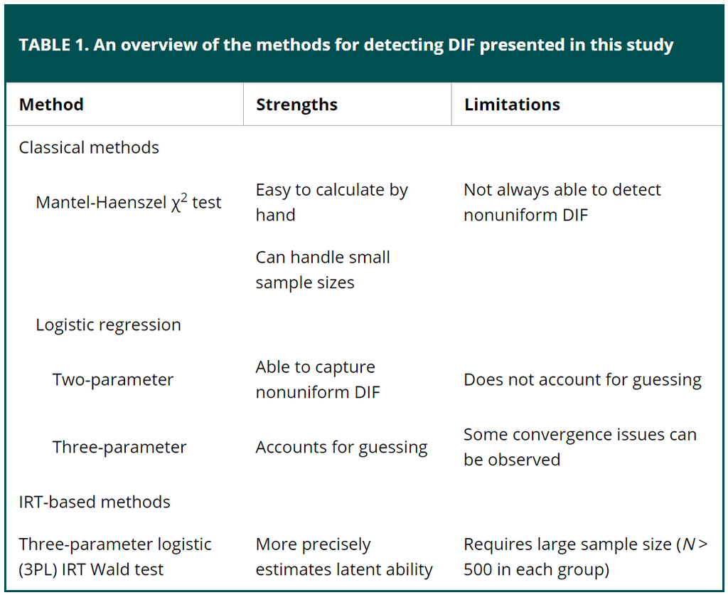

### 1.1.4

> the HCI test is fair and that the difference between the groups on the total score was due to differences in how women and men understand the concept being targeted (i.e., a true achievement gap), rather than differences in additional content necessary to understand the items

### 1.1.5

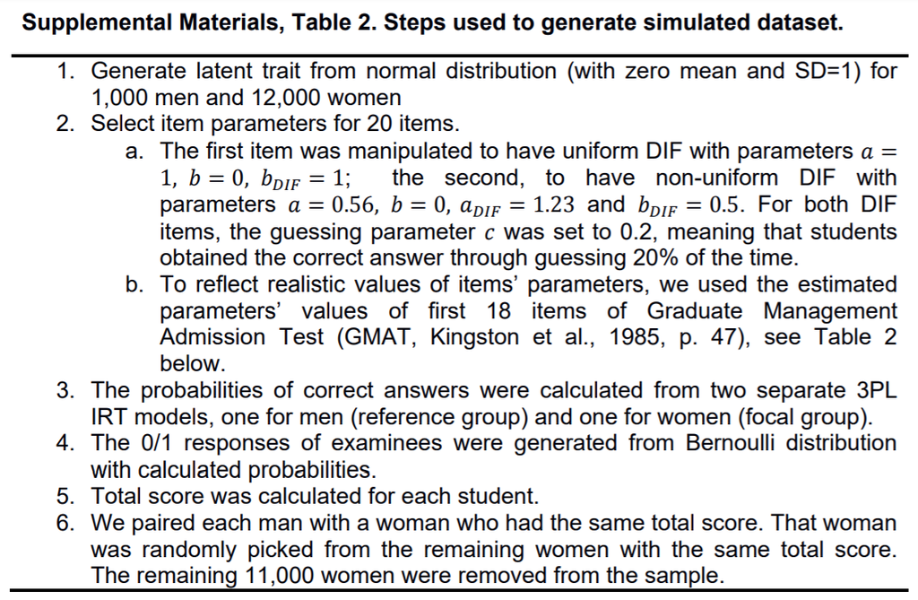

### 1.1.6

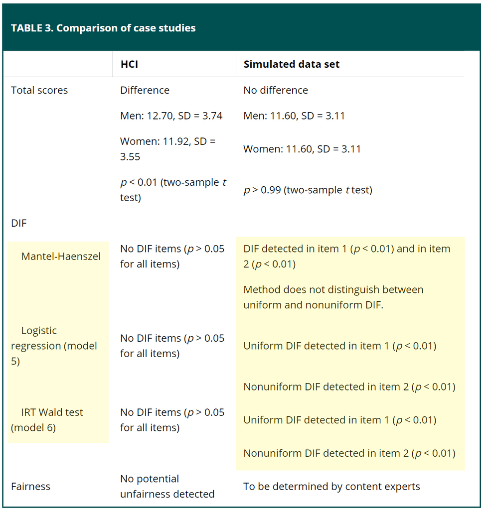

### 2.1.1

None.

### 2.1.2

Item 1.  
Detection threshold: 0.7007 (significance level: 5%)

### 2.2.1

Items 1, 2 and 7.

### 2.2.2

C, A and A.

### 2.2.3

Mantel-Haenszel estimate of odds ratio accounting for all levels of total score is equal to **2.29**. The odds of answering item 1 correctly is 2.29 times higher in the reference group than in the focal group.

For respondent who reached total score of 12 the odds of answering item 1 correctly is **2.84** times higher in the reference group than in the focal group.

### 2.2.4

Mantel-Haenszel estimate of odds ratio accounting for all levels of total score is equal to **0.77**. The odds of answering item 7 correctly is 0.77 times lower[^1] in the reference group than in the focal group.

For respondent who reached total score of 12 the odds of answering item 7 correctly is **0.58** times lower in the reference group than in the focal group[^2].

### 2.3.1

Items 1, 2 and 7.

### 2.3.2

Item 1 favours males (reference group), item 7 slightly favours females. Item 2 shows non-uniform DIF – under total score < 14, it favours males and vice versa.

### 2.3.3

With B-H correction, only items 1 and 2 retain their significance.

### 2.4.1

Items 1, 2 and 19.

### 2.4.2

Using item purification, items 1, 2, 11, 16, 19 and 20 are now significant. Convergence was reached after 3 iterations.

### 3.1.1

$N_{items} = 24$ (last two variables are “trait anger score” and “sex”)  
$N_{respondents} = 316$

### 3.1.2

Excerpt from `?difR::verbal`:

> Each item name starts with S followed by a value between 1 and 4, referring to one of the situations below:

> S1: A bus fails to stop for me.

> S2: I miss a train because a clerk gave me faulty information.

> S3: The grocery store closes just as I am about to enter.

> S4: The operator disconnects me when I had used up my last 10 cents for a call.

> The second part of the name is either Want or Do, and indicates whether the subject wanted to respond to the situation or actually did respond.

> The third part of the name is one of the possible aggressive responses, either Curse, Scold or Shout.

> For example, item S1WantShout refers to the sentence: “a bus fails to stop for me. I want to shout”. The corresponding item response is 1 if the subject agrees with that sentence, and 0 if not.

### 3.2.1

```r
library(difR)
data(verbal)

data <- verbal[, 1:24]
group <- verbal$Gender

mh_fit <- difMH(data, group, "1", purify = T)

names(verbal)[mh_fit$DIFitems] %>% pander()
```

*S2WantShout*, *S3WantScold*, *S1DoScold*, *S2DoCurse*, *S2DoScold*, *S3DoCurse*, *S3DoScold*, *S4DoCurse* and *S4DoScold*

### 3.2.2

When $\Delta_{MH} < 0$, there is DIF favouring the reference group.

### 3.2.3

```r
t(mh_fit$difPur) %>% pander()
```

|  | Step0 | Step1 | Step2 | Step3 | Step4 | Step5 | Step6 |
| --- | --- | --- | --- | --- | --- | --- | --- |
| **Item1** | 0 | 0 | 0 | 0 | 0 | 0 | 0 |
| **Item2** | 0 | 0 | 0 | 0 | 0 | 0 | 0 |
| **Item3** | 0 | 0 | 0 | 0 | 0 | 0 | 0 |
| **Item4** | 0 | 0 | 1 | 0 | 0 | 0 | 0 |
| **Item5** | 0 | 0 | 0 | 0 | 0 | 0 | 0 |
| **Item6** | 1 | 1 | 1 | 1 | 1 | 1 | 1 |
| **Item7** | 0 | 0 | 0 | 0 | 0 | 0 | 0 |
| **Item8** | 0 | 0 | 0 | 0 | 0 | 1 | 1 |
| **Item9** | 0 | 0 | 0 | 0 | 0 | 0 | 0 |
| **Item10** | 0 | 0 | 0 | 0 | 0 | 0 | 0 |
| **Item11** | 0 | 0 | 0 | 0 | 0 | 0 | 0 |
| **Item12** | 1 | 0 | 0 | 0 | 0 | 0 | 0 |
| **Item13** | 0 | 0 | 0 | 0 | 0 | 0 | 0 |
| **Item14** | 0 | 1 | 1 | 1 | 1 | 1 | 1 |
| **Item15** | 0 | 0 | 0 | 0 | 0 | 0 | 0 |
| **Item16** | 1 | 1 | 1 | 1 | 1 | 1 | 1 |
| **Item17** | 1 | 1 | 1 | 1 | 1 | 1 | 1 |
| **Item18** | 0 | 0 | 0 | 0 | 0 | 0 | 0 |
| **Item19** | 1 | 1 | 1 | 1 | 1 | 1 | 1 |
| **Item20** | 1 | 0 | 1 | 1 | 1 | 1 | 1 |
| **Item21** | 0 | 0 | 0 | 0 | 0 | 0 | 0 |
| **Item22** | 0 | 0 | 1 | 0 | 1 | 1 | 1 |
| **Item23** | 0 | 0 | 0 | 1 | 1 | 1 | 1 |
| **Item24** | 0 | 0 | 0 | 0 | 0 | 0 | 0 |

### 3.3.1

```r
log_fit <- difLogistic(data, group, "1")

names(verbal)[log_fit$DIFitems] %>% pander()
```

*S2WantShout*, *S2DoCurse*, *S2DoScold* and *S3DoCurse*

### 3.3.2

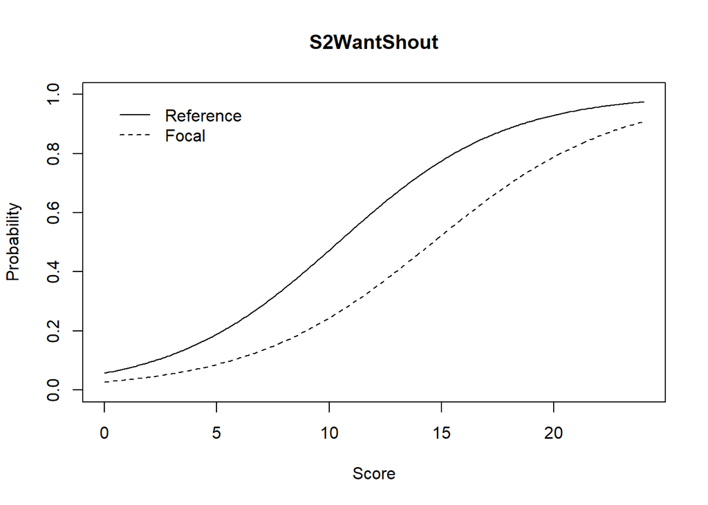

```
## The plot was not captured!
```

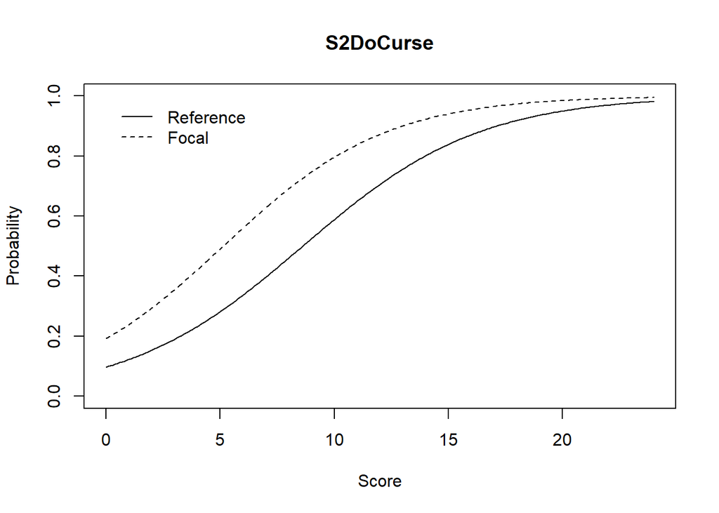

```
## The plot was not captured!
```

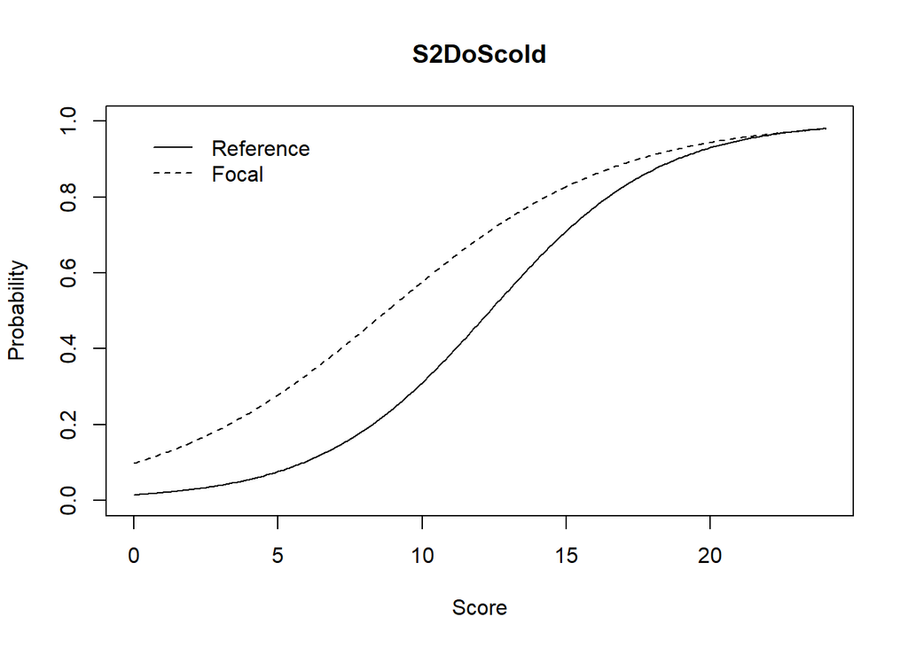

```
## The plot was not captured!
```

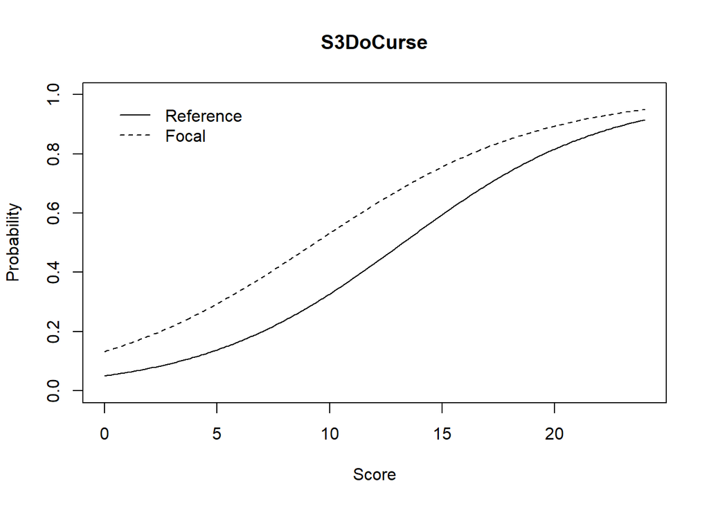

```
## The plot was not captured!
```

```r
for (i in 1:length(log_fit$DIFitems)) {
  plot(log_fit, plot = "itemCurve", item = log_fit$DIFitems[i])
}
```

### 3.3.3

Only item “S2WantShout” favours the reference group. No non-uniform DIF was detected (neither graphically nor formally with `difLogistic(data, group, "1", type = "nudif)`).

### 3.4

```r
all_fit <- dichoDif(data, group, "1", c("MH", "BD", "Logistic", "SIBTEST", "Lord", "Raju", "TID", "Std"), purify = T, p.adjust.method = "BH")

all_fit$DIF[all_fit$DIF == "NoDIF"] = 0
all_fit$DIF[all_fit$DIF == "DIF"] = 1
tbl <- apply(all_fit$DIF, 2,as.numeric)
rownames(tbl) <- rownames(all_fit$DIF)
colnames(tbl) <- c("MH", "BD", "Log", "SIB", "Lord", "Raju", "TID", "Std") # saving space...
cbind(tbl, Total = rowSums(tbl)) %>% pander()
```

|  | MH | BD | Log | SIB | Lord | Raju | TID | Std | Total |
| --- | --- | --- | --- | --- | --- | --- | --- | --- | --- |
| **S1wantCurse** | 0 | 0 | 0 | 0 | 0 | 0 | 0 | 0 | 0 |
| **S1WantScold** | 0 | 0 | 0 | 0 | 0 | 0 | 0 | 0 | 0 |
| **S1WantShout** | 0 | 0 | 0 | 0 | 0 | 0 | 0 | 0 | 0 |
| **S2WantCurse** | 0 | 0 | 0 | 0 | 0 | 0 | 0 | 0 | 0 |
| **S2WantScold** | 0 | 0 | 0 | 0 | 0 | 0 | 0 | 0 | 0 |
| **S2WantShout** | 0 | 0 | 0 | 0 | 0 | 0 | 0 | 1 | 1 |
| **S3WantCurse** | 0 | 0 | 0 | 0 | 0 | 0 | 0 | 0 | 0 |
| **S3WantScold** | 0 | 0 | 0 | 0 | 0 | 0 | 0 | 1 | 1 |
| **S3WantShout** | 0 | 0 | 0 | 0 | 0 | 0 | 0 | 0 | 0 |
| **S4WantCurse** | 0 | 0 | 0 | 0 | 0 | 0 | 0 | 0 | 0 |
| **S4WantScold** | 0 | 0 | 0 | 0 | 0 | 0 | 0 | 0 | 0 |
| **S4WantShout** | 0 | 0 | 0 | 0 | 0 | 0 | 0 | 0 | 0 |
| **S1DoCurse** | 0 | 0 | 0 | 0 | 0 | 1 | 0 | 0 | 1 |
| **S1DoScold** | 0 | 0 | 0 | 0 | 0 | 1 | 0 | 1 | 2 |
| **S1DoShout** | 0 | 0 | 0 | 0 | 0 | 0 | 0 | 0 | 0 |
| **S2DoCurse** | 1 | 0 | 0 | 0 | 1 | 1 | 0 | 1 | 4 |
| **S2DoScold** | 1 | 0 | 1 | 0 | 1 | 1 | 0 | 1 | 5 |
| **S2DoShout** | 0 | 0 | 0 | 0 | 0 | 0 | 0 | 0 | 0 |
| **S3DoCurse** | 1 | 0 | 0 | 0 | 0 | 1 | 0 | 1 | 3 |
| **S3DoScold** | 0 | 0 | 0 | 0 | 0 | 1 | 0 | 1 | 2 |
| **S3DoShout** | 0 | 0 | 0 | 0 | 0 | 0 | 0 | 0 | 0 |
| **S4DoCurse** | 0 | 0 | 0 | 0 | 0 | 1 | 0 | 1 | 2 |
| **S4DoScold** | 0 | 0 | 0 | 0 | 0 | 1 | 0 | 1 | 2 |
| **S4DoShout** | 0 | 0 | 0 | 0 | 0 | 0 | 0 | 0 | 0 |

The various DIF detection methods agree the most upon items “S2DoScold”, “S2DoCurse” and “S3DoCurse”, which have been already discussed before. These items “favours” the females in the way that they seem more aggressive within the scope of those DIF items.

### 4

Feedback in footnote.

[^1]: Shouldn’t that be “0.77 **higher**”? To my knowledge, we have to take *the reciprocal* of OR to say “lower” (or possibly reverse group order).
[^2]: Aforementioned interpretations taken directly from `ShinyItemAnalysis`.